# Practical Machine Learning Course Project

Aurelio Moya Garcia

20 April 2016

# Introduction

In this project we will analyse data from a quantified self project, in which 6 participants try to quantify how well do they perform an activity rather than how much of the activity they do. Participants were asked to perform barbell lifts correctly and incorrectly in 5 different ways, and data from accelerometers on the belt, forearm, arm, and dumbell were recorded. See more info on the [Weight Lifting Exercise Dataset.](http://groupware.les.inf.puc-rio.br/har)

We will use the [training dataset from here](https://d396qusza40orc.cloudfront.net/predmachlearn/pml-training.csv) and the [testing dataset from here.](https://d396qusza40orc.cloudfront.net/predmachlearn/pml-testing.csv)

We will predict the manner in which they did the exercise, through analysing the “classe” variable in the training set, and use a prediction model to predict 20 different test cases.

# Get and clean the data

## 1. Data sources

```r
f.training <- 'pml-training.csv'
f.test     <- 'pml-test.csv'
u.training  <- 'https://d396qusza40orc.cloudfront.net/predmachlearn/pml-training.csv'
u.test      <- 'https://d396qusza40orc.cloudfront.net/predmachlearn/pml-testing.csv'
```

## 2. Download the data

```r
download.file(u.training, f.training, method='curl')
download.file(u.test,     f.test,     method='curl')
```

## 3. Clean and preprocess the data

Read and explore the datasets

```r
tr <- read.csv(f.training, na.strings = c("", "NA", "#DIV/0!"))
te <- read.csv(f.test, na.strings = c("", "NA", "#DIV/0!"))
```

There are many empty variables (NA) and some variables that are clearly irrelevant. Remove these.

```r
d.tr <- tr[ , colSums(is.na(tr)) == 0]
d.te <- te[, colSums(is.na(te)) == 0]
d.tr <- d.tr[, -c(1:7)]
d.te <- d.te[, -c(1:7)]
```

### Model building

Slice the data into training and testing sets

```r
library(caret)
set.seed(13579)
inTrain <- createDataPartition(d.tr$classe, p=0.70, list=F)
training <- d.tr[inTrain, ]
testing <- d.tr[-inTrain, ]
```

Use a tree to classify the data

```r
treeFit <- train(classe ~ .,method="rpart",data=training)
print(treeFit$finalModel)
```

```
## n= 13737
##
## node), split, n, loss, yval, (yprob)
##       * denotes terminal node
##
##  1) root 13737 9831 A (0.28 0.19 0.17 0.16 0.18)
##    2) roll_belt< 130.5 12582 8685 A (0.31 0.21 0.19 0.18 0.11)
##      4) pitch_forearm< -26.45 1220   52 A (0.96 0.043 0 0 0) *
##      5) pitch_forearm>=-26.45 11362 8633 A (0.24 0.23 0.21 0.2 0.12)
##       10) magnet_dumbbell_y< 438.5 9594 6920 A (0.28 0.18 0.24 0.2 0.11)
##         20) roll_forearm< 122.5 5961 3561 A (0.4 0.18 0.19 0.17 0.063) *
##         21) roll_forearm>=122.5 3633 2412 C (0.075 0.17 0.34 0.24 0.18) *
##       11) magnet_dumbbell_y>=438.5 1768  856 B (0.031 0.52 0.04 0.22 0.2) *
##    3) roll_belt>=130.5 1155    9 E (0.0078 0 0 0 0.99) *
```

Let’s have a look at the tree

```r
library(rattle)
```

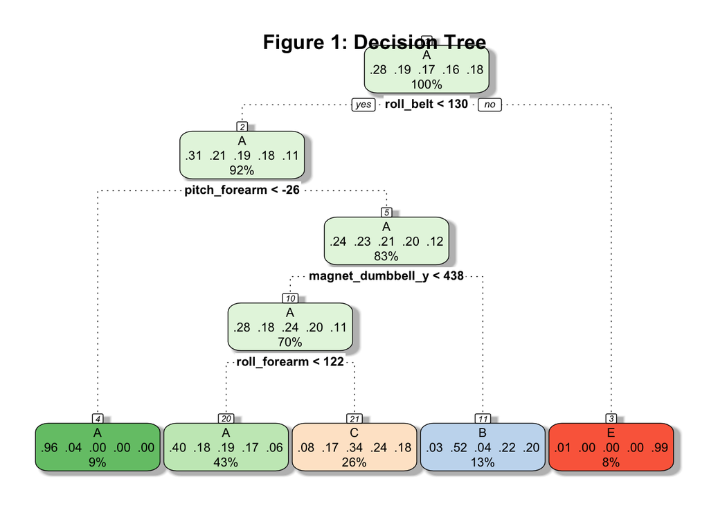

```r
tree <- treeFit$finalModel
fancyRpartPlot(treeFit$finalModel,sub = "", "Figure 1: Decision Tree")
```

The decision tree is not so good.

```r
treePred <- predict(treeFit, type = "raw")
table(training$classe, treePred)
```

```
##    treePred
##        A    B    C    D    E
##   A 3568   55  274    0    9
##   B 1126  912  620    0    0
##   C 1105   70 1221    0    0
##   D 1009  381  862    0    0
##   E  373  350  656    0 1146
```

```r
good = table(treePred == training$classe)
in.error = as.vector(100 * (1 - good["TRUE"]/sum(good)))
```

The in-sample error is 50.16 %

```r
treePred2 <- predict(treeFit, newdata = testing, type = "raw")
good.o = table(treePred2 == testing$classe)
out.error = as.vector(100 * (1 - good.o["TRUE"]/sum(good.o)))
```

The error in the testing set is 51.08 %

Let’s try a random forest clasification. We’ll get a better way to identify the important variables and high quality predictions. Using 10-fold cross validation.

```r
crf <- trainControl(method="cv", 10)
mrf <- train(classe ~ ., data=training, method="rf", trControl=crf, ntree=100)
mrf
```

```
## Random Forest
##
## 13737 samples
##    52 predictor
##     5 classes: 'A', 'B', 'C', 'D', 'E'
##
## No pre-processing
## Resampling: Cross-Validated (10 fold)
## Summary of sample sizes: 12362, 12363, 12365, 12363, 12365, 12363, ...
## Resampling results across tuning parameters:
##
##   mtry  Accuracy   Kappa      Accuracy SD  Kappa SD
##    2    0.9903903  0.9878432  0.003645750  0.004611805
##   27    0.9909727  0.9885799  0.002642347  0.003342974
##   52    0.9833296  0.9789122  0.003964697  0.005014062
##
## Accuracy was used to select the optimal model using  the largest value.
## The final value used for the model was mtry = 27.
```

The random forest classificator is much better

```r
prf <- predict(mrf, testing)
confusionMatrix(testing$classe, prf)
```

```
## Confusion Matrix and Statistics
##
##           Reference
## Prediction    A    B    C    D    E
##          A 1673    0    0    0    1
##          B   11 1124    4    0    0
##          C    0    5 1019    2    0
##          D    0    0    8  956    0
##          E    0    0    2    7 1073
##
## Overall Statistics
##
##                Accuracy : 0.9932
##                  95% CI : (0.9908, 0.9951)
##     No Information Rate : 0.2862
##     P-Value [Acc > NIR] : < 2.2e-16
##
##                   Kappa : 0.9914
##  Mcnemar's Test P-Value : NA
##
## Statistics by Class:
##
##                      Class: A Class: B Class: C Class: D Class: E
## Sensitivity            0.9935   0.9956   0.9864   0.9907   0.9991
## Specificity            0.9998   0.9968   0.9986   0.9984   0.9981
## Pos Pred Value         0.9994   0.9868   0.9932   0.9917   0.9917
## Neg Pred Value         0.9974   0.9989   0.9971   0.9982   0.9998
## Prevalence             0.2862   0.1918   0.1755   0.1640   0.1825
## Detection Rate         0.2843   0.1910   0.1732   0.1624   0.1823
## Detection Prevalence   0.2845   0.1935   0.1743   0.1638   0.1839
## Balanced Accuracy      0.9966   0.9962   0.9925   0.9945   0.9986
```

Out of sample error now is 0.6796941%.

We can have a look at the most important variables to understand how the sensors measure the quality of barbell lifts.

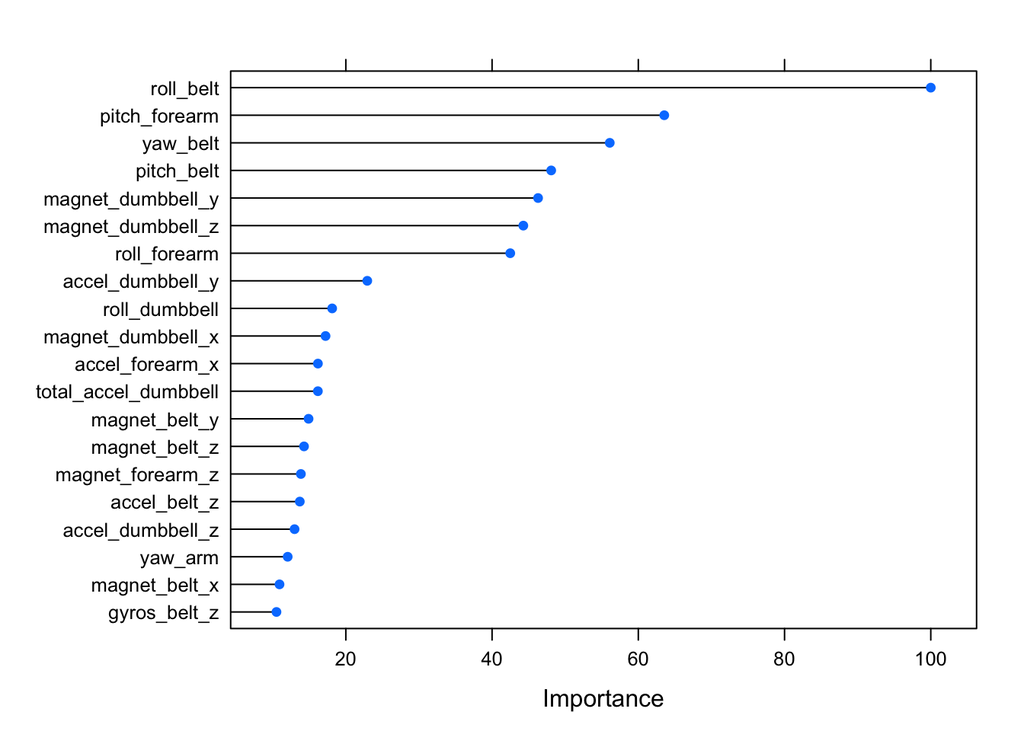

```r
plot(varImp(mrf),top = 20)
```

## 4. Prediction

We’ll use the random forest model to predict the 20 test cases.

```r
prediction <- predict(mrf, d.te)
```

The test cases will be classified as: B, A, B, A, A, E, D, B, A, A, B, C, B, A, E, E, A, B, B, B